# Predicting Attraction in Speed Dating, STAT 432 Final Project

Alan Yu NetId: ayu24

December 15, 2018

## Introduction

In this analysis, I will attempt to predict if a person will get a date based off of various qualitative and quantitative factors while also trying to understand the preferences underlying the selection of potential partners. The final decision is important (if you get a date or not), but individual decision-making are important as well. I want to figure out what kinds of qualities, characteristics and other aspects of attraction will yield the best results. “Can a machine predict if you will get a date or not”.

## Literature review

Today we live in a very fast paced world and with everything going on it is hard to focus on one thing for very long. We all want to do a lot of things or have a lot of goals but time is limited. For example, some people want to feel loved and be loved and aren’t content with being alone so something like like speed dating can be helpful and efficient for busy people or people who want to simply go out of their comfort zone and interact with others. Speed dating is a formalized matchmaking process where single people can get together and meet potential new partners in a short amount of time. Since your interactions with your potential partner is limited by time, one must make a good first impression if he or she wants to move forward and receive contact information.

This data set was created and generated by Raymond Fisman, Sheena S. Iyengar, Emir Kamenica and Itamar Simonson from the University of Columbia School of Business in 2002-2004. They used this data to for their research paper called, “Gender Differences in Mate Selection: Evidence From a Speed Dating Experiment.” The original purpose of the research was to analyze gender differences in dating preferences. They wanted to study dating behavior using an experimental speed dating market and serve as a starting point in understanding the thought process of selecting a mate. Everyone participating in the speed dating experiment get matched into pairs; male and female. they have a short, 4 minute conversation to make a good first impression. After each interaction, participants were asked to fill out a scorecard about what they thought about their potential partner. After cycling around everyone, each participant are asked who they want to date. If both feel the same way then their is match, but if either person says no then their is no match.

After conducting the experiment they found out that women cared more about intelligence and race than men did when looking for a partner whereas men cared more about physical appearance (Fisman 2006). Women also prefer men who grew up in affluent or wealthy neighborhoods while men did not have such preference. Next they studied the selectivity between women and men. In small groups, women are no more selective than males; both males and females tend to select partners of equal social value. Psychologically, this makes sense to an extend; male choice reflects women’s limited time to reproduction ability, so men seek women who “signals” that ability. Females want to seek men who can aid in supporting their offspring. In this analysis, I will try to replicate the similar results for most of these conclusions.

A similar study was done in 2017, which was lead by Samantha Joel, Paul W. Eastwick and Eli J. Finkel from the University of Utah, University of California, Davis, and Northwestern University respectively. Titled “Is Romantic Desire Predictable? Machine Learning Applied to Initial Romantic Attraction”. In their research, they were able to predict the overall tendency for someone to like and to be liked, but not if you people were a particular match for each other (Joel 2017). In the experiment, Dr. Joel gave speed daters a questionnaire about traits and preferences before starting, then after a series of 4 minute interactions, they were asked again to rate their interactions from the level of interest and sexual attraction for each person they met. Even with over 100 predictors, they did not find any predictors that could capture any meaningful variance in the data. In the end they concluded that there is still much to be done in order to understand romantic attraction and what makes two people “click”.

Bilbliography

Fisman, Raymond, et al. “Gender differences in mate selection: Evidence from a speed dating experiment.” The Quarterly Journal of Economics 121.2 (2006): 673-697.

Joel, Samantha “A Magic Formula to Predict Attraction Is More Elusive than Ever.” UNews, University of Utah, 30 Aug. 2017, unews.utah.edu/a-magic-formula-to-predict-attraction-is-more-elusive-than-ever/.

# Summary Statistics and Data Visualizations

```r
library(magrittr)
library(dplyr)
library(ggplot2)
library(GGally)
library(cowplot)
library(GGally)
library(treemap)
library(data.table)
library(corrplot)
library(caret)
library(randomForest)
library(e1071)
library(gbm)
library(glmnet)
library(MASS)
library(klaR)
library(qcc)
library(colorspace)
library(ModelMetrics)
library(kableExtra)
```

To begin our analysis, We have 2 defined groups: male and female. lets remove irrelevant columns or redundant columns based on the knowledge of the data. After spiting the data to male and female Let’s split the data into groups who managed to get a date and did not get a date.

```r
rawdata = read.csv("speed dating.csv", header = TRUE)
data = as.data.frame(rawdata)
genderSet = split(data, data$gender)
fmatchSet = split(genderSet$female, genderSet$female$match)
mmatchSet = split(genderSet$male, genderSet$male$match)
```

Since there are so many variables, it would be too lengthy to summarize all of them, so I will present the most interesting or relevant to this analysis.

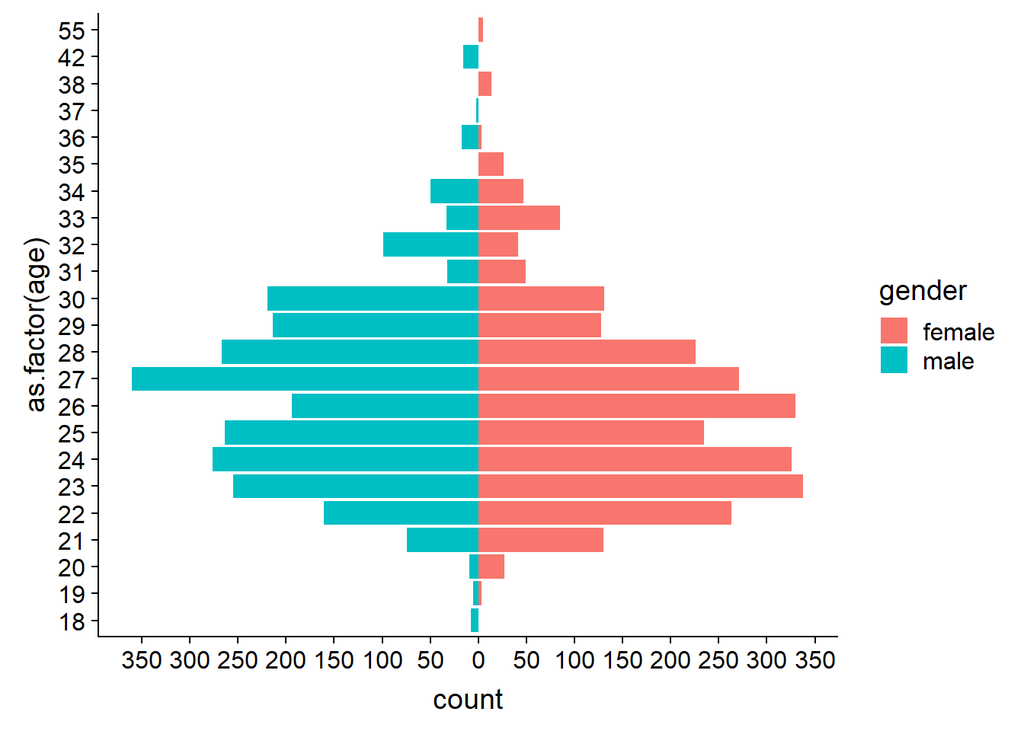

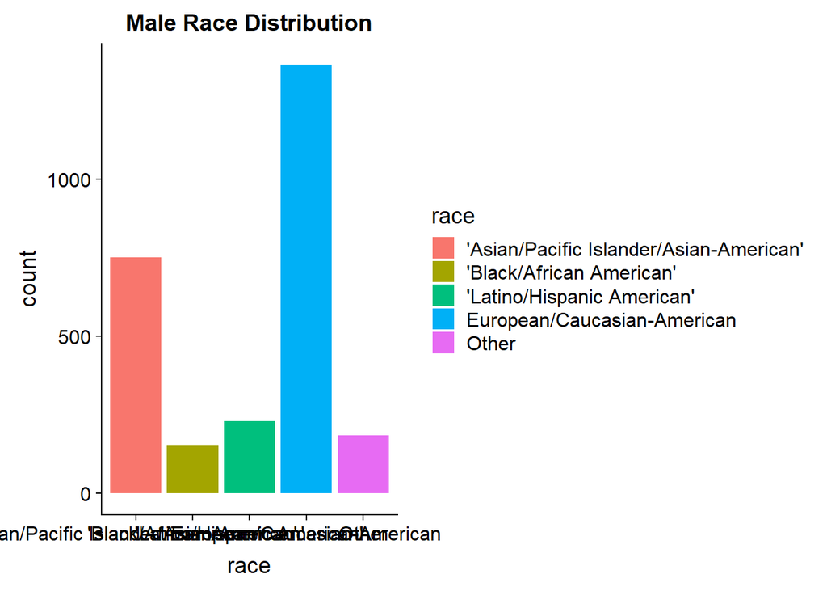

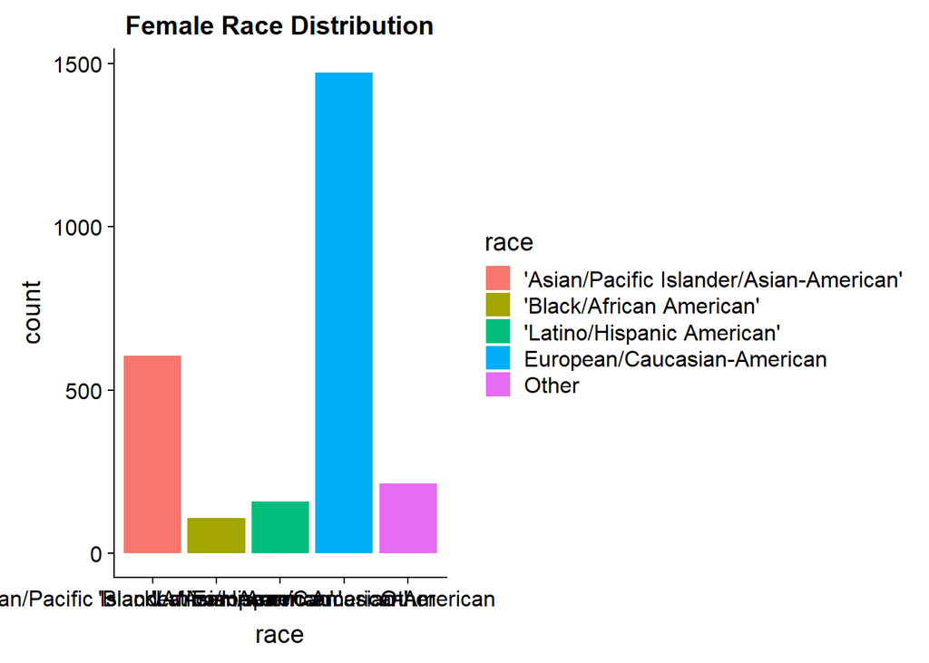

The bar plot shows European/Caucasian-Americans are over represented in this data so their preferences and values might dominate certain attribute statistics. Most people in the data set were in there 20s-30s.

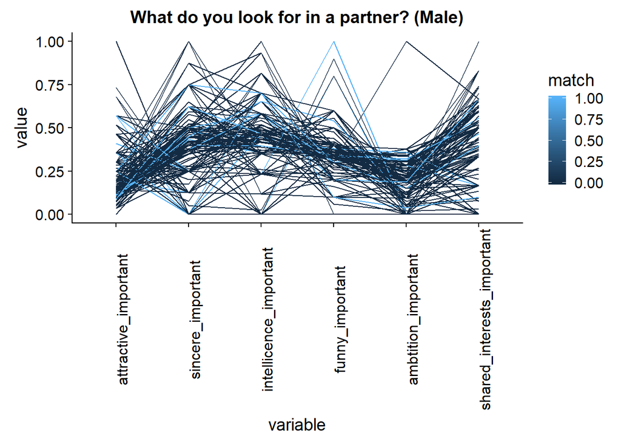

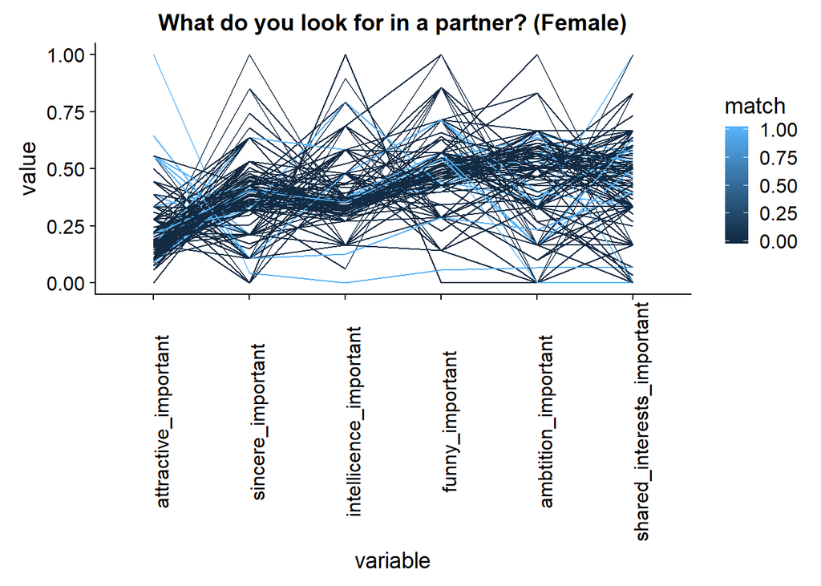

It appears that males feel that ambition is not an important attribute when looking for a partner while the over attributes are more diverse (funny not so much).

For females, most do not put importance on any one attribute, but women who placed higher importance on appearance were more likely to get a date.

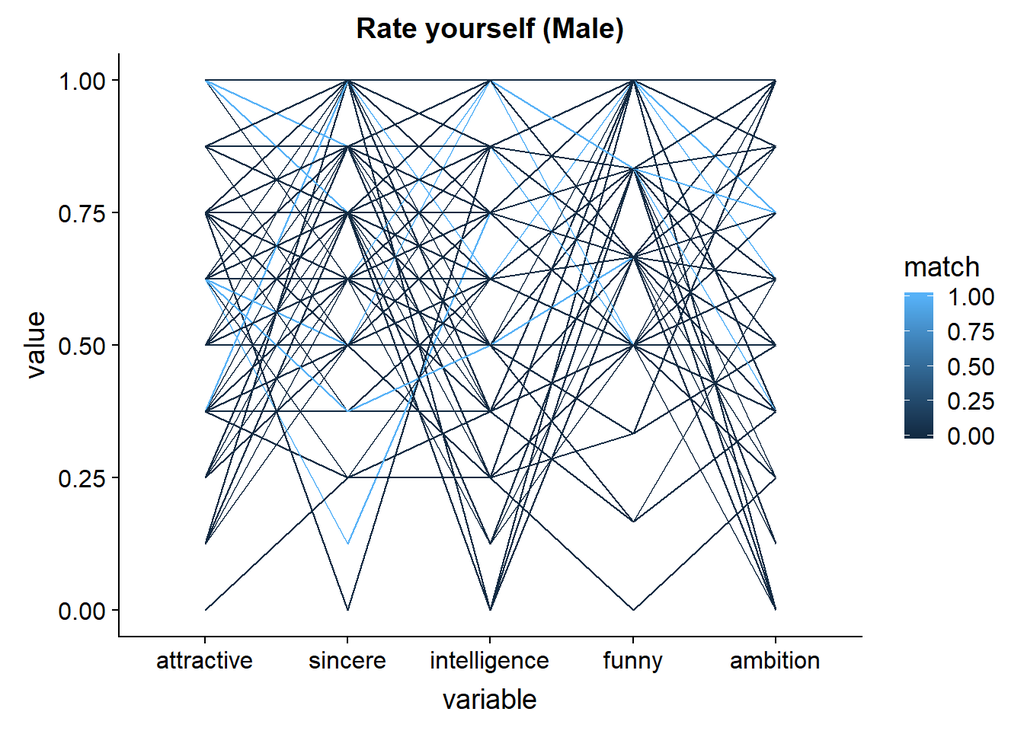

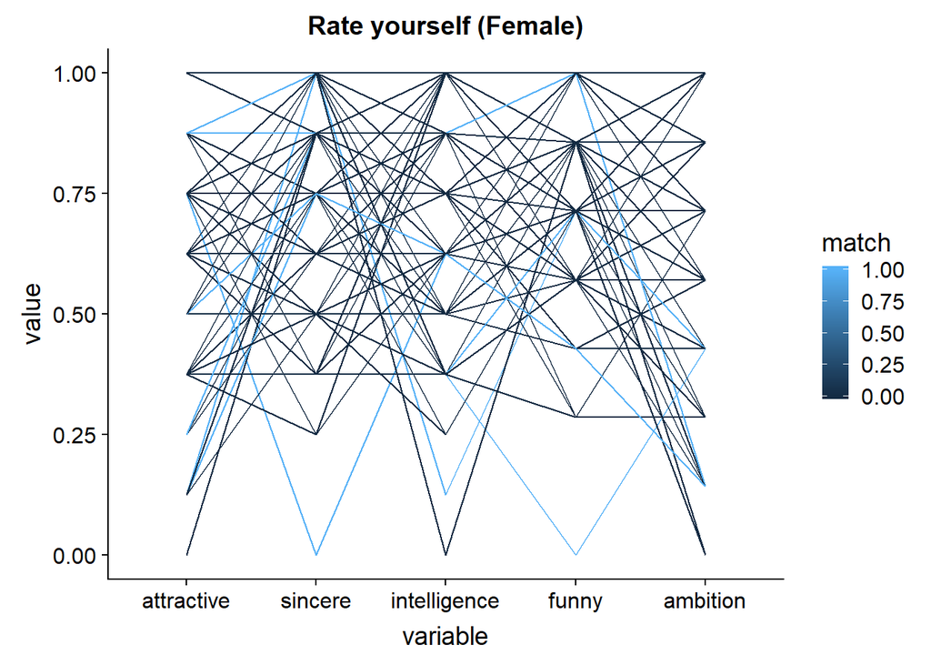

This seems like people are undervaluing their own attributes but overall there does not seem to be anything discernable from these parallel coordinate plots. This shows there is no importance placed on any one attribute. Below we will use bar charts to make this more distinct.

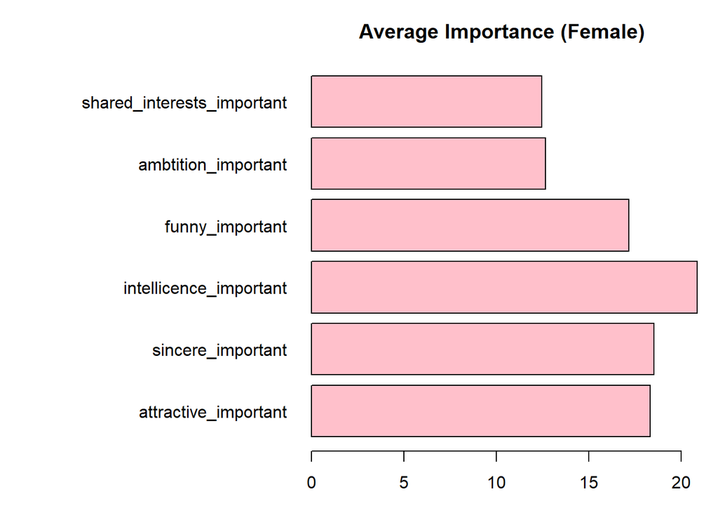

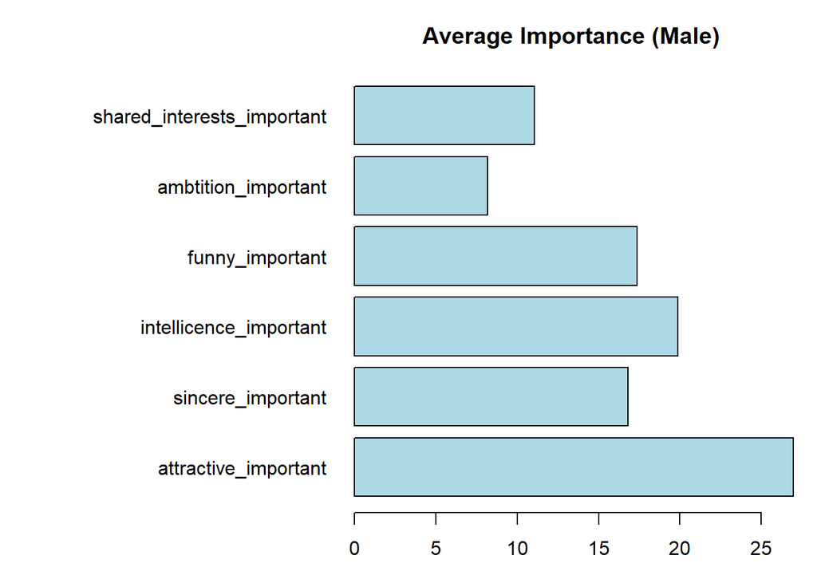

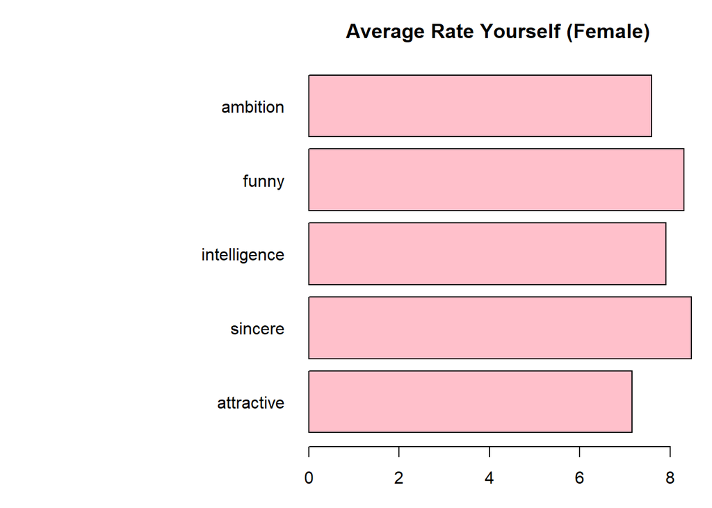

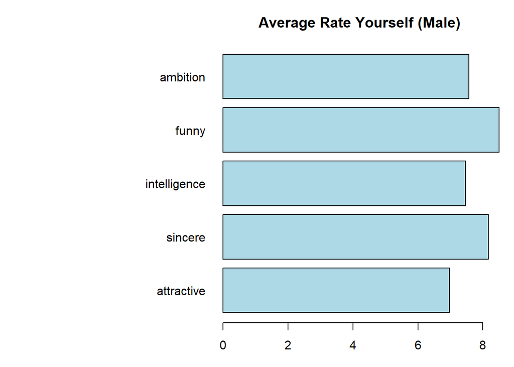

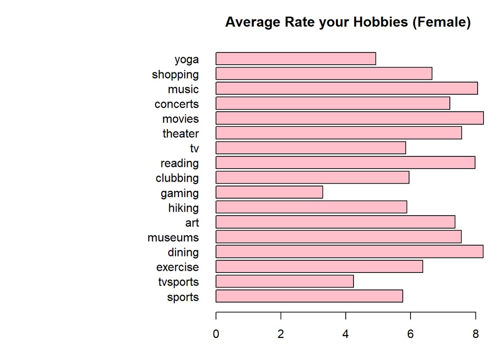

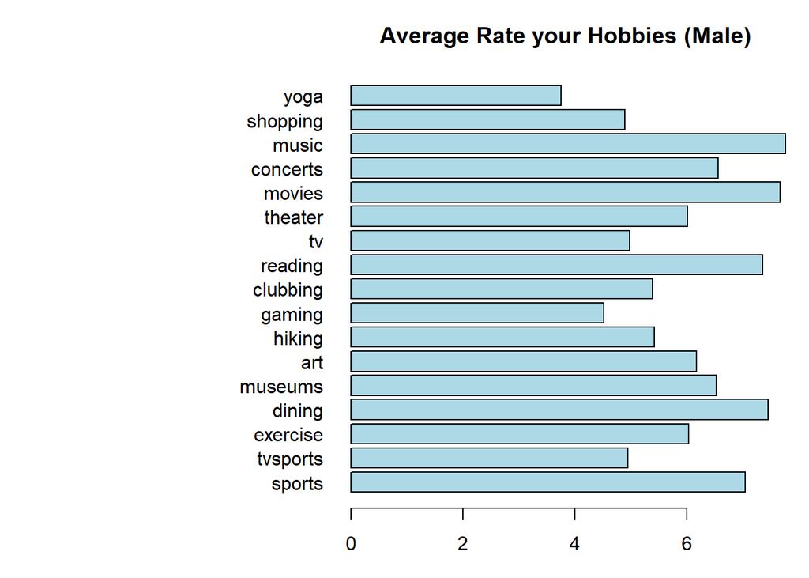

Again not nothing special sticks out, other than males valuing appearance than any category while women value intelligence the most. The hobbies chart between the two gender have some slimilarities.

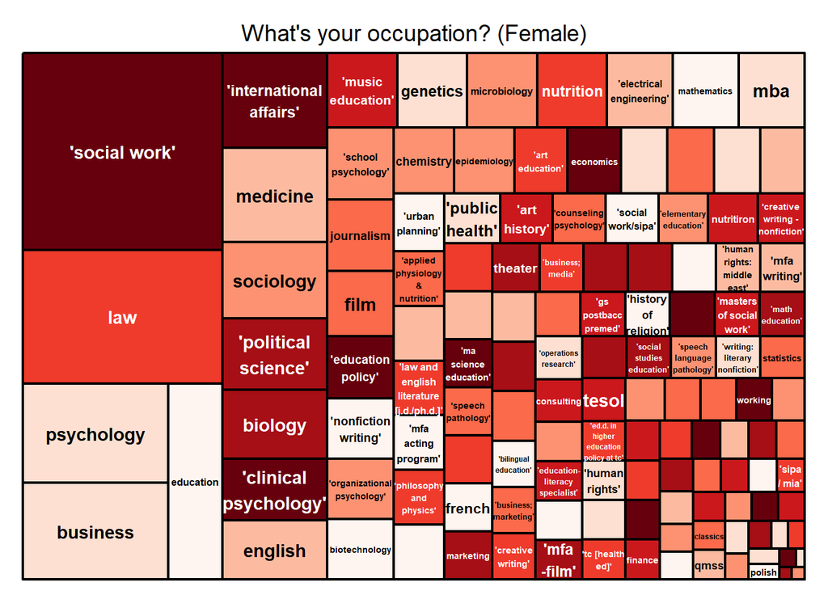

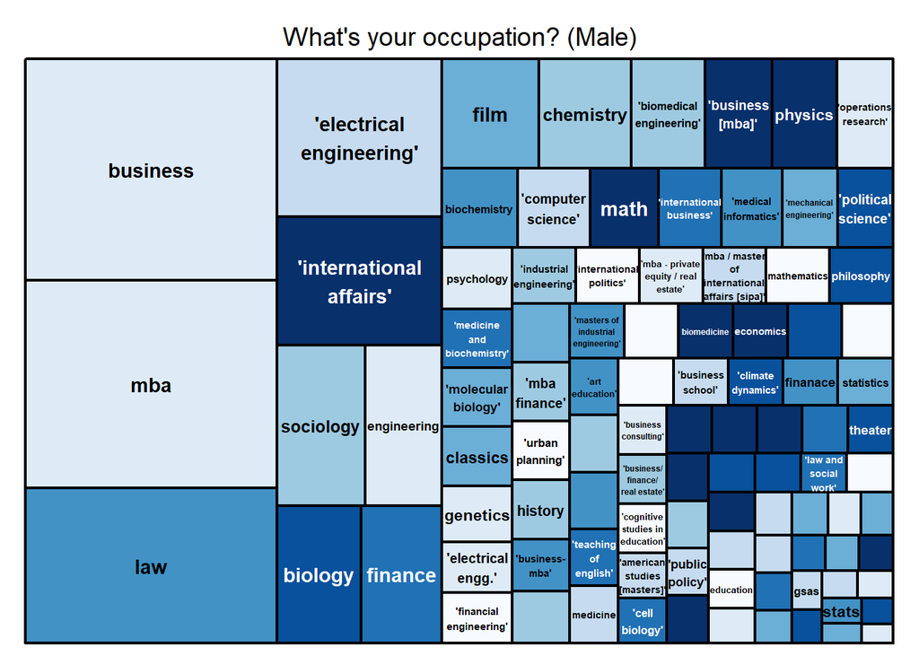

Here we can see that for males, business students were over represented in the speed dating experiment. The female major distribution is more diverse.

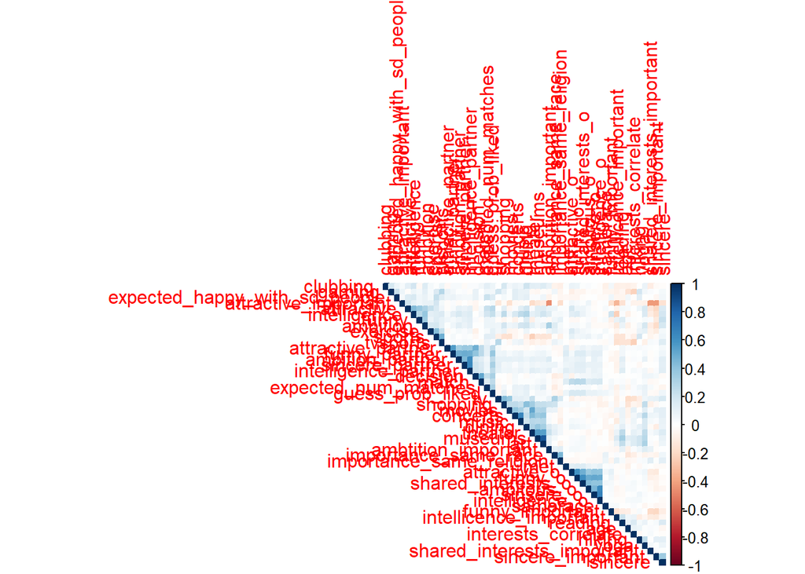

How many got a chance at a date?

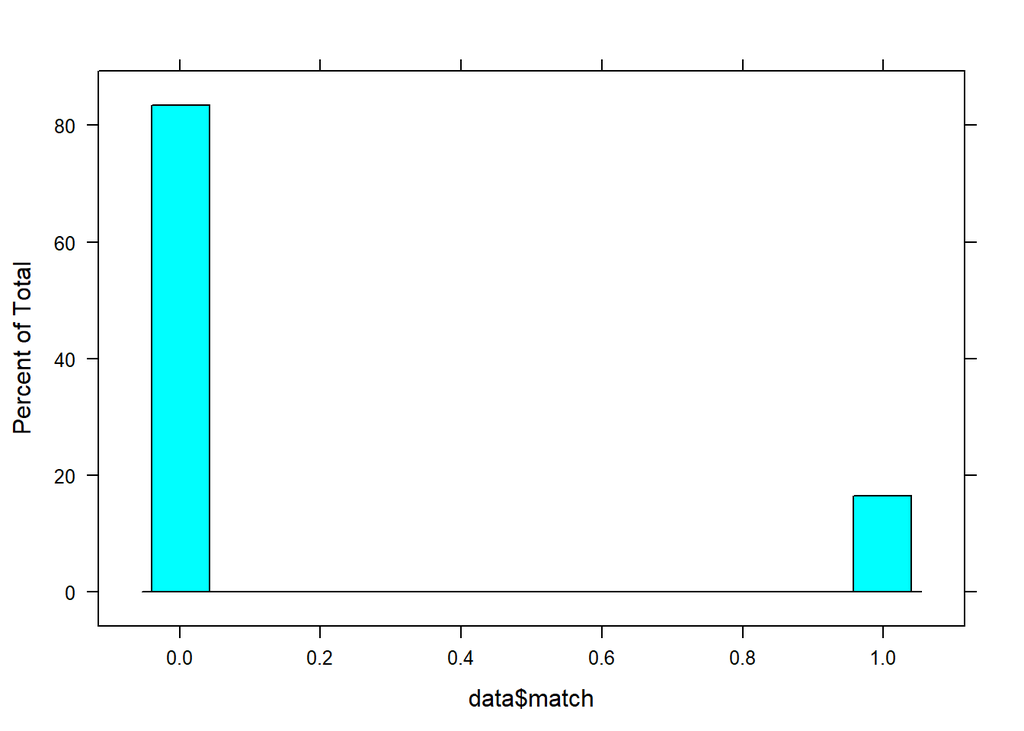

```
##   Male Female
## 0 2146   2222
## 1  409    456
```

Less than 20% of participants got a date.

Both are very similar but there is a slightly higher chance to get a date if you are a female. But Overall it is difficult to discern any meaningful conclusion based on looking at the data since everyone has different tastes and expectations and those may change again whenever you meet someone different; some maybe more accepting of your preferences and some may not.

# Analysis

To classify who got a date or not, we could try to fit a least squares estimate (linear regression model) on this data but with so many variables it may easily under fit or over fit the data. The limitation of a least squares approach is that it cannot capture all of the possible noise in the data. Instead we will use supervised learning methods such as Logistic Regression, Ridge Regression, Lasso Regression, Penalized Logistic Regression, and Boosted Trees. These methods were chosen based on prior knowledge. We will also use an unsupervised learning method (PCA).

First we need to remove the insignificant independent variables for this analysis since we do not need to know the difference in attributes (any with “d_xxx” is not relevant). split the data into train and test sets. create train and test split (80% of the data to is used to train our model and 20% of the data is to test our model). A 5 fold cross validation will be used as a compromise between good variation and computational run time.

```r
select = dplyr::select
MFData = data %>% select(-field, -d_intelligence_o, -d_funny_o, -d_shared_interests_o, -d_attractive, -d_sincere, -d_intelligence, -d_funny, -d_ambition, -d_attractive_partner, -d_sincere_partner, -d_intelligence_partner, -d_funny_partner, -d_ambition_partner, -d_shared_interests_partner, -d_sports,-d_tvsports, -d_exercise, -d_dining, -d_museums, -d_art, -d_hiking, -d_gaming, -d_clubbing, -d_reading, -d_tv, -d_theater, -d_movies, -d_concerts, -d_music, -d_shopping, -d_yoga, -d_like, -d_guess_prob_liked, -d_ambitous_o, -decision)

MFData = as.data.frame(MFData)
MFData = cbind(MFData, with(MFData, model.matrix(~ race + 0)), with(MFData, model.matrix(~ gender + 0)))
MFData = MFData %>% select(-gender, -race, -shared_interests_partner, -like, -expected_num_interested_in_me, -gendermale, -raceOther) #removed dupicate/redundant variables and variables with no variation
table(MFData$match)
```

```
##
##    0    1
## 4368  865
```

```r
trainIndex = createDataPartition(MFData$match, p = .8, list = FALSE, times = 1)
cv_5 = trainControl(method = "cv", number = 5)

MFDataTrain = MFData[trainIndex, ]
y.train = MFData[trainIndex]

MFDataTest = MFData[-trainIndex, ]
y.test = MFData[-trainIndex]
```

```
##  [1] 5.01 4.00 3.13 2.68 2.35 2.28 1.88 1.80 1.50 1.36 1.32 1.21 1.17 1.11
## [15] 1.06 1.05 0.98 0.96 0.93 0.92 0.89 0.81 0.79 0.77 0.74 0.72 0.69 0.66
## [29] 0.64 0.62 0.60 0.53 0.51 0.50 0.49 0.48 0.45 0.42 0.40 0.39 0.37 0.36
## [43] 0.34 0.33 0.32 0.29 0.27 0.27 0.26 0.26 0.12 0.01
```

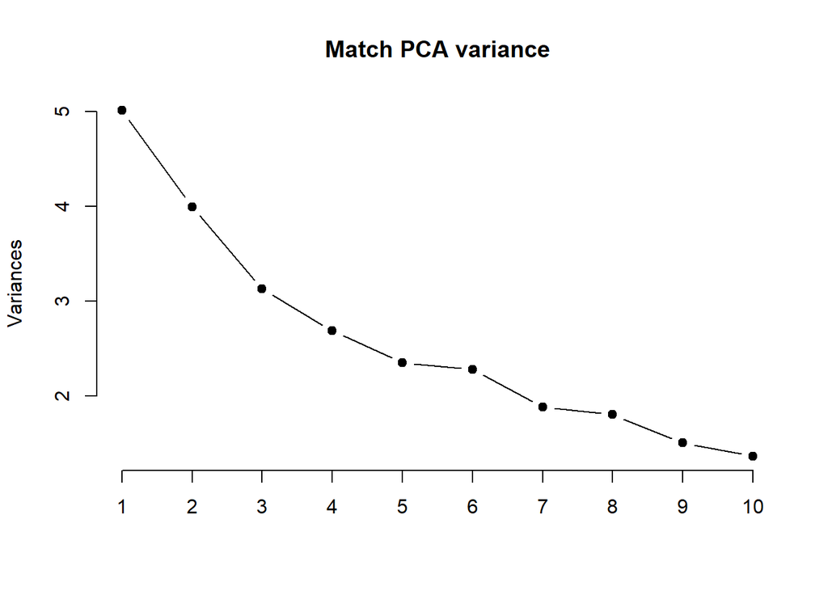

Immediately we see that the all the principle components do not capture the variance very well, so this aligns with conclusions made in Dr. Joel’s speeding dating research.

Looking at the “Match PCA Variance” plot there is not distinct “elbow” point so we use a Pareto Chart to assist in picking the ideal number of principle components. However, it still looks like the first 2 principle components are explains the variation the best.

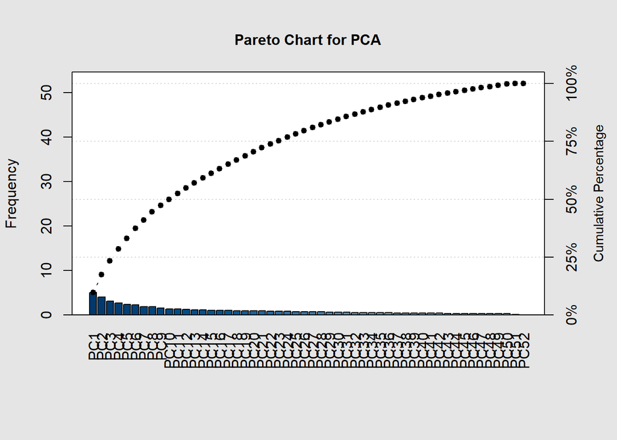

```
##
## Pareto chart analysis for PCA
##           Frequency    Cum.Freq.   Percentage Cum.Percent.
##   PC1    5.01340069   5.01340069   9.64115517   9.64115517
##   PC2    3.99540865   9.00880933   7.68347816  17.32463334
##   PC3    3.12624456  12.13505390   6.01200877  23.33664211
##   PC4    2.68456951  14.81962341   5.16263367  28.49927578
##   PC5    2.34800977  17.16763318   4.51540341  33.01467919
##   PC6    2.27788183  19.44551500   4.38054197  37.39522116
##   PC7    1.88130701  21.32682201   3.61789809  41.01311925
##   PC8    1.79890871  23.12573072   3.45943983  44.47255909
##   PC9    1.50396718  24.62969791   2.89224458  47.36480367
##   PC10   1.35843208  25.98812998   2.61236938  49.97717304
##   PC11   1.31542211  27.30355209   2.52965791  52.50683095
##   PC12   1.20850145  28.51205355   2.32404125  54.83087220
##   PC13   1.16837876  29.68043231   2.24688223  57.07775444
##   PC14   1.11008108  30.79051339   2.13477132  59.21252575
##   PC15   1.05988199  31.85039538   2.03823459  61.25076034
##   PC16   1.04633061  32.89672599   2.01217425  63.26293459
##   PC17   0.98215093  33.87887692   1.88875179  65.15168638
##   PC18   0.95739353  34.83627045   1.84114140  66.99282778
##   PC19   0.92661170  35.76288214   1.78194557  68.77477335
##   PC20   0.92392461  36.68680675   1.77677809  70.55155145
##   PC21   0.89177390  37.57858066   1.71494981  72.26650126
##   PC22   0.80702767  38.38560833   1.55197629  73.81847756
##   PC23   0.79403813  39.17964646   1.52699641  75.34547396
##   PC24   0.76579545  39.94544191   1.47268355  76.81815752
##   PC25   0.74410991  40.68955181   1.43098059  78.24913810
##   PC26   0.71701700  41.40656881   1.37887884  79.62801694
##   PC27   0.68524583  42.09181464   1.31778044  80.94579738
##   PC28   0.66211231  42.75392694   1.27329290  82.21909028
##   PC29   0.64455341  43.39848035   1.23952578  83.45861606
##   PC30   0.62482991  44.02331026   1.20159598  84.66021204
##   PC31   0.60100859  44.62431885   1.15578575  85.81599779
##   PC32   0.52947937  45.15379822   1.01822956  86.83422735
##   PC33   0.50812173  45.66191995   0.97715718  87.81138453
##   PC34   0.50401339  46.16593334   0.96925652  88.78064104
##   PC35   0.48729468  46.65322802   0.93710516  89.71774620
##   PC36   0.47802722  47.13125525   0.91928312  90.63702932
##   PC37   0.44855659  47.57981184   0.86260883  91.49963815
##   PC38   0.41790007  47.99771191   0.80365399  92.30329214
##   PC39   0.39766024  48.39537215   0.76473123  93.06802337
##   PC40   0.38866432  48.78403647   0.74743138  93.81545475
##   PC41   0.36670968  49.15074615   0.70521092  94.52066567
##   PC42   0.36383457  49.51458072   0.69968187  95.22034753
##   PC43   0.34343625  49.85801697   0.66045433  95.88080187
##   PC44   0.33418314  50.19220011   0.64265989  96.52346175
##   PC45   0.31996595  50.51216607   0.61531914  97.13878090
##   PC46   0.29459950  50.80676556   0.56653750  97.70531839
##   PC47   0.27065357  51.07741914   0.52048764  98.22580604
##   PC48   0.26841238  51.34583152   0.51617765  98.74198368
##   PC49   0.26265867  51.60849019   0.50511283  99.24709652
##   PC50   0.25725861  51.86574880   0.49472811  99.74182462
##   PC51   0.12255952  51.98830833   0.23569139  99.97751601
##   PC52   0.01169167  52.00000000   0.02248399 100.00000000
```

```r
sum(cov$Variance[1:2]) # % explained variance
```

```
## [1] 17.32
```

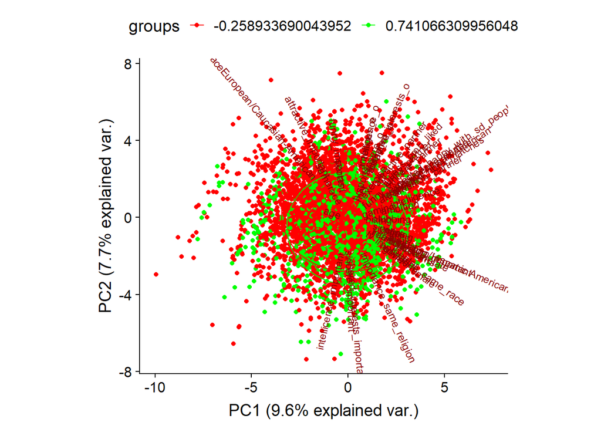

```r
g = ggbiplot::ggbiplot(pca, choices = 1:2, obs.scale = 1, var.scale = 1, groups = factor(dataMC[,49]), ellipse = T, circle = T)
g+theme(legend.position='top') + scale_colour_manual(values=c('red','green'))
```

Red indicates no date and Green indicates yes to a date. There is no clear seperation being the two groups. Even using PCA does not yield high explained variance so we will move on to modeling.

```r
#set-up the full model
MFDataTrain$match = as.factor(MFDataTrain$match)
full_model  = formula(match ~ .)

accuracy = function(actual, predicted) {
  mean(actual == predicted)
}
```

Simple logistic regression model with all the variables.

```r
MFDataTrain = MFData[trainIndex, ]
MFDataTest = MFData[-trainIndex, ]

log_model = glm(match ~., MFDataTrain, family = binomial)
summary(log_model)
```

```
##
## Call:
## glm(formula = match ~ ., family = binomial, data = MFDataTrain)
##
## Deviance Residuals:
##     Min       1Q   Median       3Q      Max
## -2.4611  -0.5220  -0.3008  -0.1308   3.1238
##
## Coefficients:
##                                                Estimate Std. Error z value
## (Intercept)                                   -7.315906   3.069039  -2.384
## age                                            0.001080   0.015400   0.070
## samerace                                       0.013032   0.112701   0.116
## importance_same_race                          -0.028378   0.022928  -1.238
## importance_same_religion                       0.032550   0.022260   1.462
## attractive_o                                   0.310798   0.036821   8.441
## sinsere_o                                     -0.049298   0.044204  -1.115
## intelligence_o                                 0.073788   0.055665   1.326
## funny_o                                        0.175289   0.042438   4.131
## ambitous_o                                    -0.125692   0.041899  -3.000
## shared_interests_o                             0.221335   0.032935   6.720
## attractive_important                          -0.012792   0.029357  -0.436
## sincere_important                             -0.026281   0.029933  -0.878
## intellicence_important                         0.006618   0.030306   0.218
## funny_important                               -0.009154   0.029644  -0.309
## ambtition_important                           -0.012395   0.029261  -0.424
## shared_interests_important                    -0.022816   0.030114  -0.758
## attractive                                    -0.130678   0.052266  -2.500
## sincere                                        0.037608   0.042931   0.876
## intelligence                                  -0.054986   0.043553  -1.262
## funny                                          0.036880   0.057851   0.637
## ambition                                      -0.039630   0.036820  -1.076
## attractive_partner                             0.314018   0.035235   8.912
## sincere_partner                               -0.064257   0.045859  -1.401
## intelligence_partner                           0.101888   0.055126   1.848
## funny_partner                                  0.208671   0.040516   5.150
## ambition_partner                              -0.103260   0.039444  -2.618
## sports                                        -0.034052   0.027342  -1.245
## tvsports                                      -0.038095   0.024473  -1.557
## exercise                                      -0.008587   0.025108  -0.342
```

[output cut: 74 more lines]

```
## `race'Asian/Pacific Islander/Asian-American'`  0.62263
## `race'Black/African American'`                 0.45837
## `race'Latino/Hispanic American'`               0.71610
## `raceEuropean/Caucasian-American`              0.18942
## genderfemale                                   0.79572
## ---
## Signif. codes:  0 '***' 0.001 '**' 0.01 '*' 0.05 '.' 0.1 ' ' 1
##
## (Dispersion parameter for binomial family taken to be 1)
##
##     Null deviance: 3737.9  on 4186  degrees of freedom
## Residual deviance: 2697.6  on 4133  degrees of freedom
## AIC: 2805.6
##
## Number of Fisher Scoring iterations: 6
```

```r
phat = predict(log_model, newdata = MFDataTest, type = "response")

predtype = ifelse(phat > .5, '0', '1')
errorRate = mean(predtype != MFDataTest$match)
1 - errorRate
```

```
## [1] 0.1606119
```

```r
log_model2 = glm(match ~ importance_same_religion + attractive_o + funny_o + ambitous_o + shared_interests_o + sincere + funny + attractive_partner + tvsports + art + guess_prob_liked, data = MFDataTrain, family = binomial)

summary(log_model2)
```

```
##
## Call:
## glm(formula = match ~ importance_same_religion + attractive_o +
##     funny_o + ambitous_o + shared_interests_o + sincere + funny +
##     attractive_partner + tvsports + art + guess_prob_liked, family = binomial,
##     data = MFDataTrain)
##
## Deviance Residuals:
##     Min       1Q   Median       3Q      Max
## -2.4516  -0.5495  -0.3321  -0.1526   3.0166
##
## Coefficients:
##                          Estimate Std. Error z value Pr(>|z|)
## (Intercept)              -8.66657    0.55983 -15.481  < 2e-16 ***
## importance_same_religion  0.01280    0.01737   0.737  0.46103
## attractive_o              0.26059    0.03390   7.686 1.52e-14 ***
## funny_o                   0.20045    0.03978   5.039 4.67e-07 ***
## ambitous_o               -0.09806    0.03631  -2.701  0.00692 **
## shared_interests_o        0.21077    0.03139   6.715 1.88e-11 ***
## sincere                  -0.01119    0.03562  -0.314  0.75343
## funny                    -0.08434    0.04668  -1.807  0.07079 .
## attractive_partner        0.40006    0.02910  13.745  < 2e-16 ***
## tvsports                 -0.02965    0.01777  -1.669  0.09517 .
## art                       0.03135    0.02187   1.433  0.15174
## guess_prob_liked          0.23975    0.02492   9.621  < 2e-16 ***
## ---
## Signif. codes:  0 '***' 0.001 '**' 0.01 '*' 0.05 '.' 0.1 ' ' 1
##
## (Dispersion parameter for binomial family taken to be 1)
##
##     Null deviance: 3737.9  on 4186  degrees of freedom
## Residual deviance: 2827.1  on 4175  degrees of freedom
## AIC: 2851.1
##
## Number of Fisher Scoring iterations: 6
```

```r
phat = predict(log_model2, newdata = MFDataTest, type = "response")

predtype = ifelse(phat > .5, '0', '1')
errorRate = mean(predtype != MFDataTest$match)
1 - errorRate
```

```
## [1] 0.1596558
```

fit another reduced model

```r
log_model3 = glm(match ~ attractive_o + funny_o + ambitous_o + shared_interests_o + sincere + funny + attractive_partner + art + guess_prob_liked, data = MFDataTrain, family = binomial)

phat = predict(log_model3, newdata = MFDataTest, type = "response")

predtype = ifelse(phat > .5, '0', '1')
errorRate = mean(predtype != MFDataTest$match)
1 - errorRate
```

```
## [1] 0.1558317
```

After running a couple of models the prediction rate seems to plateau at ~15% prediction rate, that is to say, this model can predict if you will get a date ~15% of the time.

Ridge and Lasso Regression

```r
MFDataTrain = MFData[trainIndex, ]
y.train = MFData$match[trainIndex]
MFDataTrain = data.matrix(MFDataTrain)
y.train = data.matrix(y.train)

MFDataTest = MFData[-trainIndex, ]
MFDataTest = data.matrix(MFDataTest)
y.test = MFData$match[-trainIndex]
y.test = data.matrix(y.test)

ridge_model = cv.glmnet(MFDataTrain, y.train, alpha = 0)
lasso_model = cv.glmnet(MFDataTrain, y.train, alpha = 1)

y_hat_ridge = predict(ridge_model, MFDataTest)
y_hat_lasso = predict(lasso_model, MFDataTest)


sum((y.test - y_hat_ridge)^2)
```

```
## [1] 1.835515
```

```r
sum((y.test - y_hat_ridge)^2)
```

```
## [1] 1.835515
```

```r
lambda_ridge = expand.grid(alpha = 0, lambda = c(ridge_model$lambda.min, ridge_model$lambda.1se))
train_ridge = train(MFDataTrain[,-49], MFDataTrain[,49], method = "glmnet", trControl = cv_5, tuneGrid = lambda_ridge)

lambda_lasso = expand.grid(alpha = 1, lambda = c(lasso_model$lambda.min, lasso_model$lambda.1se))
train_lasso = train(MFDataTrain[, -49], MFDataTrain[,49], method = "glmnet", trControl = cv_5,tuneGrid = lambda_lasso)

method = c("Lasso", "Ridge")
cv_acc = c(train_lasso$results$RMSE, train_ridge$results$RMSE)
sd_cv_acc = c(train_lasso$results$RMSESD, train_ridge$results$RMSESD)
param_value = c(train_lasso$results$lambda, train_ridge$results$lambda)

results = data.frame(method, param_value, cv_acc, sd_cv_acc)
colnames(results) = c("Method", "Parameter Value", "CV-5 Accuracy", "Standard Deviation")
kable_styling(kable(results, format = "html", digits = 3), full_width = FALSE)
```

| Method | Parameter Value | CV-5 Accuracy | Standard Deviation |
| --- | --- | --- | --- |
| Lasso | 0.012 | 0.332 | 0.009 |
| Ridge | 0.041 | 0.331 | 0.009 |

Boosted Tree Model with a large tuning grid with a small interaction.depth and small shrinkage values.

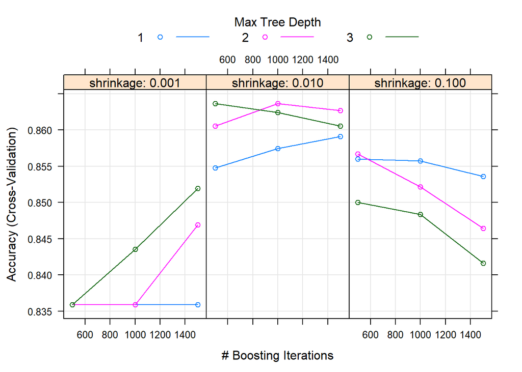

```r
MFDataTrain = MFData[trainIndex, ]
y.train = MFData[trainIndex]

MFDataTest = MFData[-trainIndex, ]
y.test = MFData[-trainIndex]
MFDataTrain$match = as.factor(MFDataTrain$match)
gbm_grid  = expand.grid(interaction.depth = c(1:3), n.trees = 1:3 * 500,
                        shrinkage = c(0.001, 0.01, 0.1), n.minobsinnode = 10)
gbm_full  = train(full_model, data = MFDataTrain, method = "gbm",
                  verbose = FALSE, trControl = cv_5, tuneGrid = gbm_grid)
plot(gbm_full)
```

```r
gbm_full$bestTune
```

```
##    n.trees interaction.depth shrinkage n.minobsinnode
## 14    1000                 2      0.01             10
```

```r
gbm_full$finalModel
```

```
## A gradient boosted model with bernoulli loss function.
## 1000 iterations were performed.
## There were 53 predictors of which 49 had non-zero influence.
```

```r
accuracy(predict(gbm_full, MFDataTest), MFDataTest$match)
```

```
## [1] 0.8460803
```

```r
rmse(predict(gbm_full, MFDataTest), MFDataTest$match)
```

```
## [1] 0.9802056
```

Below is a penalized logistic regression, we will use a tuneLength of 5 so caret will try 5 $\alpha$ values and some $\lambda$ values for each.

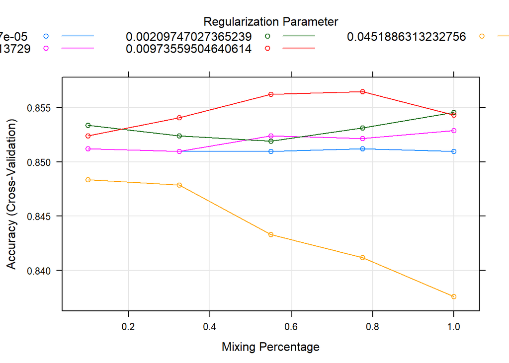

```r
MFDataTrain$match = as.factor(MFDataTrain$match)
glmn_full  = train(full_model, data = MFDataTrain, method = "glmnet", trControl = cv_5, tuneLength = 5)

plot(glmn_full)
```

```r
glmn_full$bestTune
```

```
##    alpha      lambda
## 19 0.775 0.009735595
```

```r
accuracy(predict(glmn_full, MFDataTest), MFDataTest$match)
```

```
## [1] 0.8432122
```

```r
rmse(predict(glmn_full, MFDataTest), MFDataTest$match)
```

```
## [1] 0.957011
```

Comparing the accuracy and root mean squared error between the penalized logistic regression and the boosted tree model, the boosted tree model model has slightly better accuracy over the penalized logistic regression but the penalized logistic regression has a slightly smaller root mean squared error. Overall it looks like the boosted tree model is the “best” model so we will move forward with that.

```r
par(mar=c(3, 20, 3, 1))
#summary(gbm_full$finalModel, las = 1)
```

# Conclusion

In the end, the boosted tree model performed the best out of all models used in this analysis. Based on the model we went forward with the best way to get a date is to just be a likable person and take care of your appearance. If you are attractive, funny your chances of getting a date is higher. Unlike in the research done by Fisman, race was not determined to be a significant factor in this model. The potential pitfall of this analysis is that accuracies vary with each run of certain models (Ridge, Lasso and Boosted Tree) so I made sure to run them multiple times to ensure a consistant accuracy and reasonable output. Many variables were excluded due to redundancy but it could be possible a significant variable was removed. Runtime was considered in this analysis (particularly, tunelength was reduced from 10 because it was taking a very long time to complete). There could also be a possibility that the tuning parameters are not the most optimal solution.

It should be noted that the subjects used in the data set were graduate students or professional degree students at Columbia University and also people who self-selected themselves to participate so there could be a selection bias. This also explains the distribution of the population chart from earlier. Therefore this data is not representative of the general population or an indicator of what attributes does society favor the most. This study was over a decade old which means society and technology were very different back then (this is what people thought about back then). Love is complicated, A relationship between two people is more than just a sum of a hundred variables, there is a unique interaction that happens when you meet someone; that can’t be predicted. Everyone has their own unique attributes and values that it would be hard to predict effectively. This model could not capture all the possible “right things to have” because it ultimately depends on you and the person you are talking to think. Sometimes it just comes down to luck and being in the right place at the right time. Future work in this dataset could try using neural networks or a sophisticated random forest model that can accomidate more variables/parameters. Random forest and neural networks are both very compuationally intense and running these model in R would take a lot of memory and the run time would be very long.